# Importing libraries and data

```python
import pandas as pd
import numpy as np
import matplotlib.pyplot as plt
import seaborn as sns
import calendar
from datetime import datetime
from pandas import Series
from math import ceil
```

```python
df = pd.read_csv("video_game.csv")
```

```python
df = df.dropna()
df.head()
```

|  | Id | Name | Platform | Year_of_Release | Genre | Publisher | NA_players | EU_players | JP_players | Other_players | Global_players | Critic_Score | Critic_Count | User_Score | User_Count | Developer | Rating |
| --- | --- | --- | --- | --- | --- | --- | --- | --- | --- | --- | --- | --- | --- | --- | --- | --- | --- |
| 0 | 1 | Wii Sports | Wii | 2006.0 | Sports | Nintendo | 41.36 | 20.96 | 3.77 | 0.45 | 40.53 | 76.0 | 51.0 | 8 | 322.0 | Nintendo | E |
| 2 | 3 | Mario Kart Wii | Wii | 2008.0 | Racing | Nintendo | 15.68 | 10.76 | 3.79 | 3.29 | 35.52 | 82.0 | 73.0 | 8.3 | 709.0 | Nintendo | E |
| 3 | 4 | Wii Sports Resort | Wii | 2009.0 | Sports | Nintendo | 15.61 | 10.93 | 3.28 | 0.95 | 30.77 | 80.0 | 73.0 | 8 | 192.0 | Nintendo | E |
| 6 | 7 | New Super Mario Bros. | DS | 2006.0 | Platform | Nintendo | 11.28 | 9.14 | 6.50 | 0.88 | 29.40 | 89.0 | 65.0 | 8.5 | 431.0 | Nintendo | E |
| 7 | 8 | Wii Play | Wii | 2006.0 | Misc | Nintendo | 13.96 | 9.18 | 0.93 | 0.84 | 20.92 | 58.0 | 41.0 | 6.6 | 129.0 | Nintendo | E |

```python
df.shape
```

```
(6825, 17)
```

```python
df.isna().sum()
```

```
Id                 0
Name               0
Platform           0
Year_of_Release    0
Genre              0
Publisher          0
NA_players         0
EU_players         0
JP_players         0
Other_players      0
Global_players     0
Critic_Score       0
Critic_Count       0
User_Score         0
User_Count         0
Developer          0
Rating             0
dtype: int64
```

```python
df.dtypes
```

```
Id                   int64
Name                object
Platform            object
Year_of_Release    float64
Genre               object
Publisher           object
NA_players         float64
EU_players         float64
JP_players         float64
Other_players      float64
Global_players     float64
Critic_Score       float64
Critic_Count       float64
User_Score          object
User_Count         float64
Developer           object
Rating              object
dtype: object
```

As we can see, the User_Score feature has strings as values, this will not be good for analysis, therefore we convert it to numeric data.

```python
df['User_Score'] = df['User_Score'].astype(float)
```

# Initial conclusions

```python
df[['Genre','User_Score']].groupby(['Genre'], as_index = False).mean()
```

|  | Genre | User_Score |
| --- | --- | --- |
| 0 | Action | 7.095828 |
| 1 | Adventure | 7.160887 |
| 2 | Fighting | 7.301852 |
| 3 | Misc | 6.849740 |
| 4 | Platform | 7.377171 |
| 5 | Puzzle | 7.250847 |
| 6 | Racing | 7.104303 |
| 7 | Role-Playing | 7.618539 |
| 8 | Shooter | 7.086458 |
| 9 | Simulation | 7.196633 |
| 10 | Sports | 7.110817 |
| 11 | Strategy | 7.352809 |

Opinion:

```python
df[['Genre','Critic_Score']].groupby(['Genre'], as_index = False).mean()
```

|  | Genre | Critic_Score |
| --- | --- | --- |
| 0 | Action | 67.828834 |
| 1 | Adventure | 66.133065 |
| 2 | Fighting | 69.732804 |
| 3 | Misc | 67.460938 |
| 4 | Platform | 70.000000 |
| 5 | Puzzle | 70.694915 |
| 6 | Racing | 69.543890 |
| 7 | Role-Playing | 72.820225 |
| 8 | Shooter | 70.981481 |
| 9 | Simulation | 69.969697 |
| 10 | Sports | 74.170732 |
| 11 | Strategy | 73.123596 |

The above table shows that Critics are most appreciative of Sports, followed by Strategy and Role-Playing(RPG) games.

Opinion:

There is clearly a shift in the scores of critics compared to users. Usually it is found that critics do not buy the games and the critic scores are largely based on online viewing of gameplays. Therefore a game that may be great when playing on your own might not be so appealing when gameplays are the mode of judgement.

```python
df[['Genre','NA_players','EU_players','JP_players']].groupby(['Genre'], as_index=False).mean()
```

|  | Genre | NA_players | EU_players | JP_players |
| --- | --- | --- | --- | --- |
| 0 | Action | 0.314865 | 0.218270 | 0.045503 |
| 1 | Adventure | 0.156492 | 0.101048 | 0.035202 |
| 2 | Fighting | 0.334365 | 0.149471 | 0.068386 |
| 3 | Misc | 0.510547 | 0.272031 | 0.065677 |
| 4 | Platform | 0.415881 | 0.259454 | 0.087072 |
| 5 | Puzzle | 0.266949 | 0.186780 | 0.126949 |
| 6 | Racing | 0.346971 | 0.259312 | 0.034010 |
| 7 | Role-Playing | 0.263385 | 0.147753 | 0.141110 |
| 8 | Shooter | 0.415231 | 0.258241 | 0.021493 |
| 9 | Simulation | 0.283232 | 0.219832 | 0.074613 |
| 10 | Sports | 0.419427 | 0.209364 | 0.034507 |
| 11 | Strategy | 0.117041 | 0.094419 | 0.016255 |

The above table shows us the genre preferance of North American, European, and Japanese players with respect to Genre.

If you wonder why Japanese players are considered as a seperate entity altogether, well, 2 of the major gaming platforms, namely Sony and Nintendo are Japanese companies

```python
df[['Platform','NA_players','EU_players','JP_players']].groupby(['Platform'], as_index=False).mean()
```

|  | Platform | NA_players | EU_players | JP_players |
| --- | --- | --- | --- | --- |
| 0 | 3DS | 0.275290 | 0.176323 | 0.139161 |
| 1 | DC | 0.110000 | 0.020714 | 0.190000 |
| 2 | DS | 0.339224 | 0.196767 | 0.150129 |
| 3 | GBA | 0.309662 | 0.137553 | 0.059620 |
| 4 | GC | 0.275661 | 0.088879 | 0.046322 |
| 5 | PC | 0.076436 | 0.154869 | 0.000261 |
| 6 | PS | 0.505067 | 0.363867 | 0.219000 |
| 7 | PS2 | 0.356711 | 0.201000 | 0.061237 |
| 8 | PS3 | 0.368817 | 0.314044 | 0.070897 |
| 9 | PS4 | 0.301925 | 0.400753 | 0.038870 |
| 10 | PSP | 0.199231 | 0.120846 | 0.054769 |
| 11 | PSV | 0.084153 | 0.074322 | 0.064576 |
| 12 | Wii | 0.657432 | 0.342651 | 0.084280 |
| 13 | WiiU | 0.277416 | 0.206966 | 0.114270 |
| 14 | X360 | 0.509825 | 0.240478 | 0.011760 |
| 15 | XB | 0.260584 | 0.088920 | 0.002124 |
| 16 | XOne | 0.387296 | 0.226541 | 0.001824 |

The above table shows us the genre preferance of North American, European, and Japanese players with respect to Gaming Platform.

If you wonder why Japanese players are considered as a seperate entity altogether, well, 2 of the major gaming platforms, namely Sony and Nintendo are Japanese companies

# Plotting graphs

Popularity of Diffrent Genres

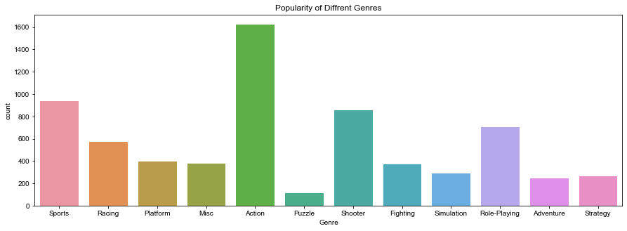

```python
plt.figure(figsize=(15,5))
plt.title('Popularity of Diffrent Genres')
sns.set_style('whitegrid')
sns.countplot(x='Genre',data=df)
plt.show()
```

Trends of Diffrent Genres and Rating

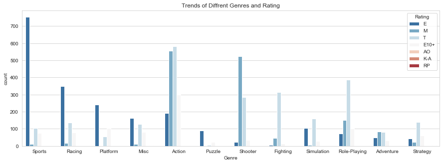

```python
#rating vs genre
plt.figure(figsize=(15,5))
plt.title('Trends of Diffrent Genres and Rating')
sns.set_style('whitegrid')
sns.countplot(x='Genre',hue='Rating',data=df, palette='RdBu_r')
plt.show()
```

Popularity of Diffrent Platforms

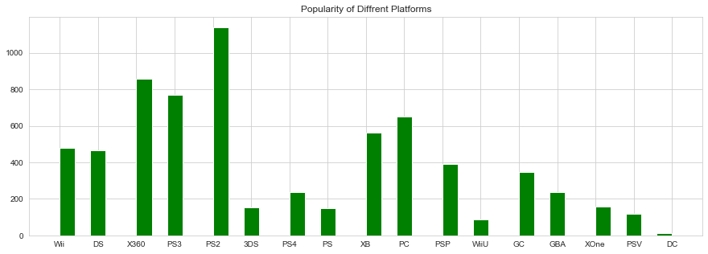

```python
#platform most polpular to play
df['Platform'].hist(color='green',bins=40,figsize=(15,5))
plt.title('Popularity of Diffrent Platforms')
```

Players across the world according to nationality

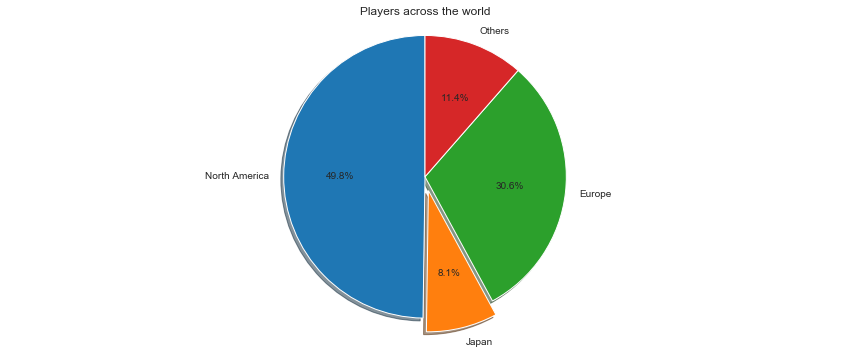

```python
# Pie chart, where the slices will be ordered and plotted counter-clockwise:
labels = ['North America', 'Japan', 'Europe', 'Others']
sizes = [sum(df.NA_players), sum(df.JP_players), sum(df.EU_players), sum(df.Other_players)]
explode = (0, 0.1, 0, 0)  # only "explode" the 2nd slice (i.e. 'Hogs')

fig1, ax1 = plt.subplots(figsize=(15,6))
ax1.pie(sizes, explode=explode, labels=labels, autopct='%1.1f%%',
        shadow=True, startangle=90)
ax1.axis('equal')  # Equal aspect ratio ensures that pie is drawn as a circle.
plt.title('Players across the world')
plt.show()
```

Sales of different genres according to the platforms

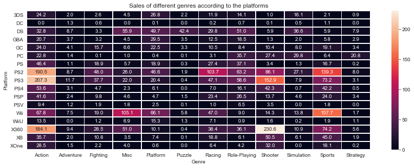

```python
plt.figure(figsize=(15,5))
platform_genre_sales = df.pivot_table(
                        index='Platform',
                        columns='Genre',
                        values='Global_players',
                        aggfunc=sum).fillna(0).applymap(float)
sns.heatmap(platform_genre_sales, annot=True, fmt=".1f", linewidths=.5);
plt.title('Sales of different genres according to the platforms')
plt.show()
```

# Finding the top values

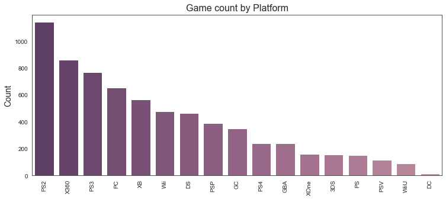

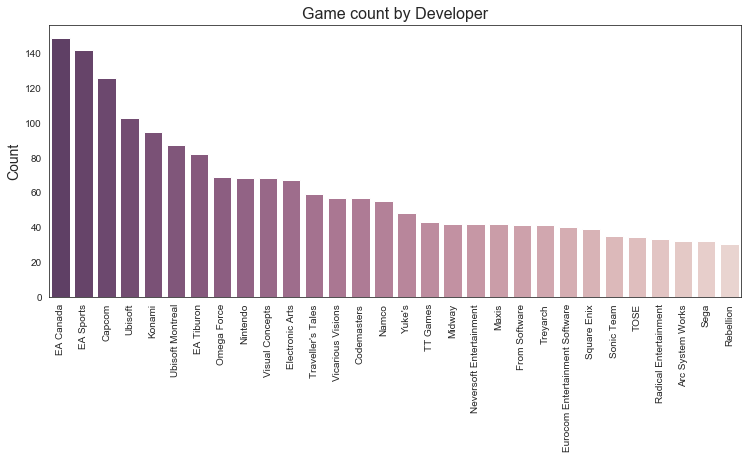

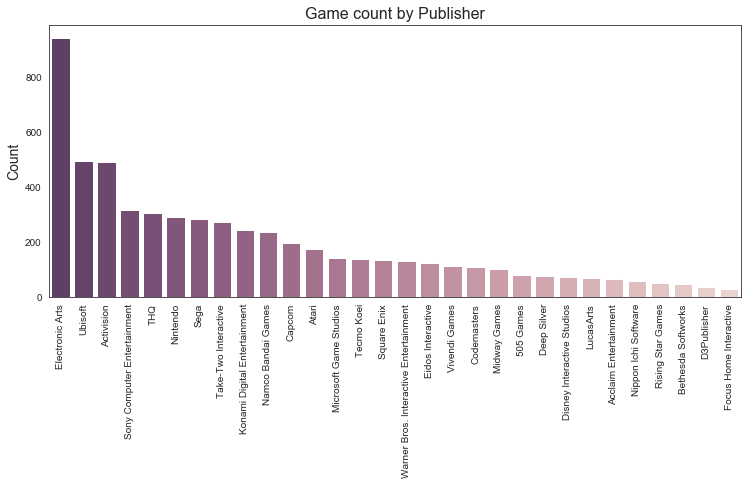

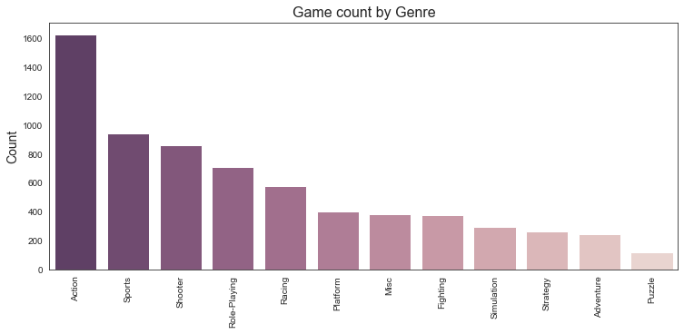

```python
cols = ['Platform', 'Developer', 'Publisher', 'Genre']

for col in cols:
    chart = df[['Name', col]].groupby([col]).count().sort_values('Name', ascending=False).reset_index()
    sns.set_style("white")
    plt.figure(figsize=(12.4, 5))
    plt.xticks(rotation=90)
    sns.barplot(x=col, y='Name', data=chart[:30], palette=sns.cubehelix_palette((12 if col == 'Genre' else 30), dark=0.3, light=.85, reverse=True)).set_title(('Game count by '+col), fontsize=16)
    plt.ylabel('Count', fontsize=14)
    plt.xlabel('')
```

Sales vs. critic scores By platform, developer, publisher, and genre

```python
def score_group(score):
    if score >= 90:
        return '90-100'
    elif score >= 80:
        return '80-89'
    elif score >= 70:
        return '70-79'
    elif score >= 60:
        return '60-69'
    elif score >= 50:
        return '50-59'
    else:
        return '0-49'
```

```python
dfh = df
dfh['Score_Group'] = dfh['Critic_Score'].apply(lambda x: score_group(x))
```

```python
def in_top(x):
    if x in pack:
        return x
    else:
        pass
def width(x):
    if x == 'Platform':
        return 14.4
    elif x == 'Developer':
        return 13.2
    elif x == 'Publisher':
        return 11.3
    elif x == 'Genre':
        return 13.6

def height(x):
    if x == 'Genre':
        return 8
    else:
        return 9
```

# Dataset correlations

```python
#Conversion of categorical columns into numeric codes
```

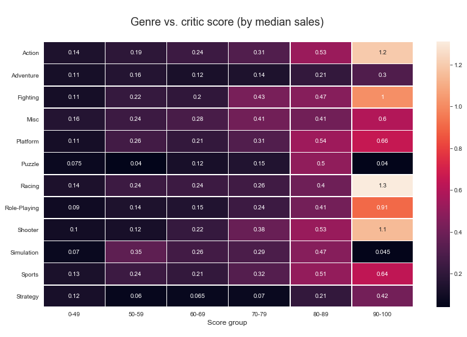

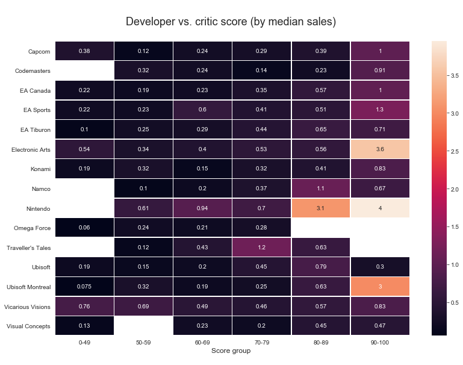

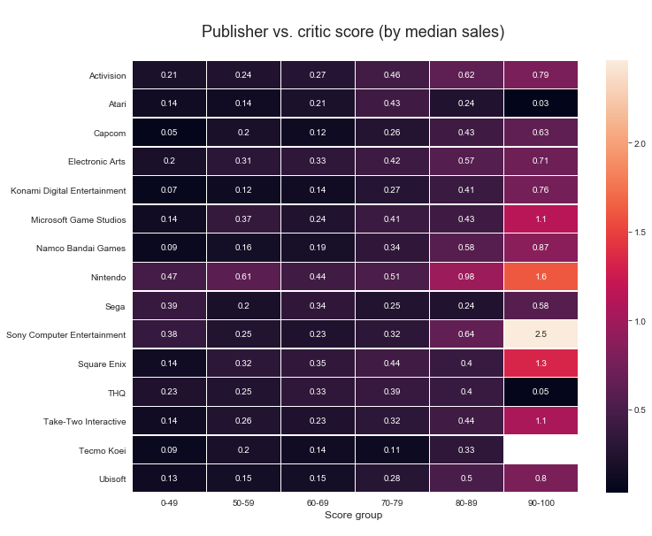

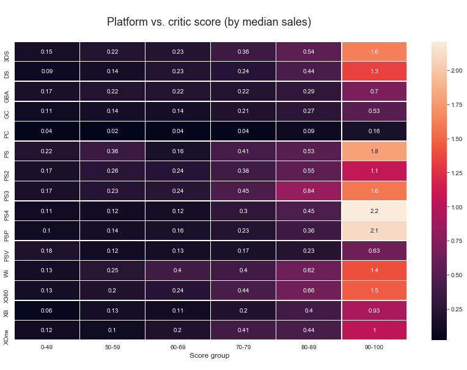

```python
cols = ['Genre', 'Developer', 'Publisher', 'Platform']
for col in cols:
    pack = []
    top = dfh[['Name', col]].groupby([col]).count().sort_values('Name', ascending=False).reset_index()[:15]
    for x in top[col]:
        pack.append(x)
    dfh[col] = dfh[col].apply(lambda x: in_top(x))
    dfh_platform = dfh[[col, 'Score_Group', 'Global_players']].groupby([col, 'Score_Group']).median().reset_index().pivot(col, "Score_Group", "Global_players")
    plt.figure(figsize=(width(col), height(col)))
    sns.heatmap(dfh_platform, annot=True, fmt=".2g", linewidths=.5).set_title((' \n'+col+' vs. critic score (by median sales) \n'), fontsize=18)
    plt.ylabel('', fontsize=14)
    plt.xlabel('Score group \n', fontsize=12)
    pack = []
```

```python
cols = ['Platform', 'Genre', 'Publisher', 'Developer', 'Rating']
for col in cols:
    uniques = df[col].value_counts().keys()
    uniques_dict = {}
    ct = 0
    for i in uniques:
        uniques_dict[i] = ct
        ct += 1

    for k, v in uniques_dict.items():
        df.loc[df[col] == k, col] = v
```

```python
df1 = df[['Platform','Genre','Publisher','Year_of_Release','Critic_Score','Global_players']]
df1 = df1.dropna().reset_index(drop=True)
df1 = df1.astype('float64')
```

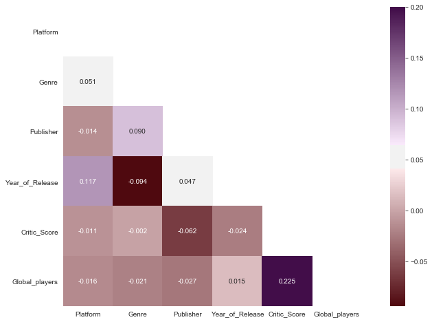

```python
mask = np.zeros_like(df1.corr())
mask[np.triu_indices_from(mask)] = True
cmap = sns.diverging_palette(730, 300, sep=20, as_cmap=True, s=85, l=15, n=20) # note: 680, 350/470
with sns.axes_style("white"):
    fig, ax = plt.subplots(1,1, figsize=(15,8))
    ax = sns.heatmap(df1.corr(), mask=mask, vmax=0.2, square=True, annot=True, fmt=".3f", cmap=cmap)
```

Strongest correlations are:

Critic scores-to-global sales: We'll take a closer look at this below.

Year of release-to-platform: This makes sense since new platforms come out periodically.

# Critic scores to global sales

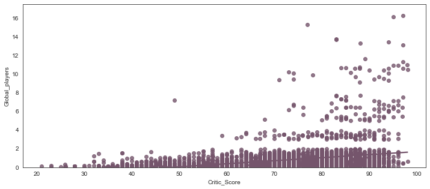

```python
fig, ax = plt.subplots(1,1, figsize=(12,5))
sns.regplot(x="Critic_Score", y="Global_players", data=df1, ci=None, color="#75556c", x_jitter=.02).set(ylim=(0, 17.5))
plt.show()
```

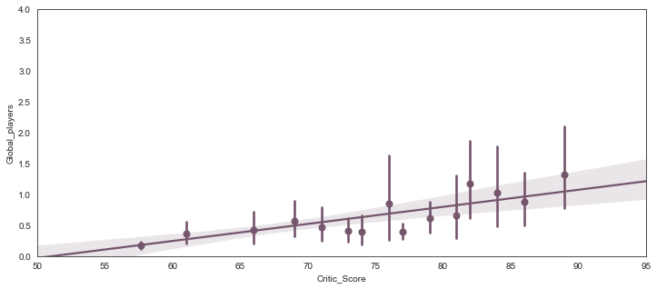

```python
fig, ax = plt.subplots(1,1, figsize=(12,5))
sns.regplot(x="Critic_Score", y="Global_players", data=df1.loc[df1.Year_of_Release >= 2014],
            truncate=True, x_bins=15, color="#75556c").set(ylim=(0, 4), xlim=(50, 95))
plt.show()
```

The relationship looks much clearer now. It's interesting how the slope gets steeper in the 80's. It seems once a game gets a high critic score, every additional point has a higher impact. Go big or go home, right?

Looks like critic scores will be a good feature for the prediction model in section 2.

# Defining hits as those with sales above 1 million units

This will be the target in our prediction model, where we'll predict if a game will be a hit or not.

```python
dfb = df[['Name','Platform','Genre','Publisher','Year_of_Release','Critic_Score','Global_players']]
dfb = dfb.dropna().reset_index(drop=True)
df2 = dfb[['Platform','Genre','Publisher','Year_of_Release','Critic_Score','Global_players']]
df2['Hit'] = df2['Global_players']
df2.drop('Global_players', axis=1, inplace=True)
```

```python
def hit(sales):
    if sales >= 1:
        return 1
    else:
        return 0

df2['Hit'] = df2['Hit'].apply(lambda x: hit(x))
```

Let's graph the relationship between critic scores and VG hits using a 5% sample...

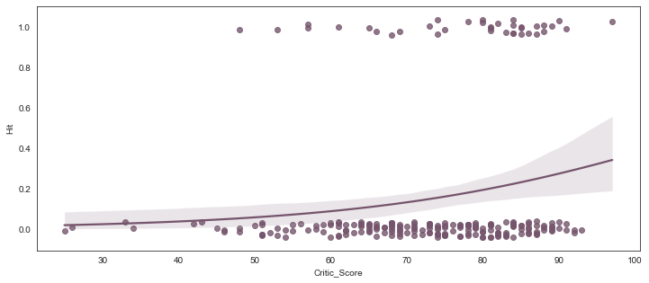

```python
# Logistic regression plot with sample of the data
n = ceil(0.05 * len(df2['Hit']))
fig, ax = plt.subplots(1,1, figsize=(12,5))
sns.regplot(x="Critic_Score", y="Hit", data=df2.sample(n=n),
            logistic=True, n_boot=500, y_jitter=.04, color="#75556c")
plt.show()
```

As expected, it seems hits are mostly found near high critic scores, while non-hits can vary in scores but don't have as strong of a presence in the high score ranges (as seen in the steepening regression curve near the 70's).